# Violencia intrafamiliar en Guatemala (2008-2023)

Análisis de las denuncias registradas por el INE

Autores/as

Juan Luarca

Roberto Calderón

Carlos Vela

Mayda Matul

Fecha de publicación

11 de noviembre de 2026

# Resumen ejecutivo

Se analizan 590,672 denuncias de violencia intrafamiliar registradas en Guatemala entre 2008 y 2023. Los hallazgos principales son:

- **Es una violencia de género y de pareja.** En el 83.0 % de las denuncias la víctima es una mujer y el agresor un hombre, y en el 77.7 % el agresor es la pareja o expareja. Un segundo patrón, la violencia entre generaciones, explica buena parte de las víctimas hombres.
- **La violencia física pierde peso.** Pasa del 67 % de las denuncias en 2008 al 43 % en 2023. Lo más probable es que se denuncie antes, no que haya menos violencia.
- **Las niñas son el grupo de mayor riesgo de violencia sexual**: aparece en el 30 % de las denuncias de niñas menores de 14 años, frente al 3 % en mujeres de 19 a 40.
- **El confinamiento de 2020 redujo las denuncias entre un 21 % y un 31 %** de marzo a junio: denuncias que no se hicieron, no violencia que no ocurrió.
- **Hay señales de subregistro**: el altiplano indígena tiene las tasas de denuncia más bajas del país.
- **Un modelo de regresión logística** confirma que la violencia física se asocia a ser mujer o menor de edad, a convivir en pareja con el agresor, a la baja escolaridad y a ser indígena, aun controlando por las demás variables. Pero su capacidad predictiva es modesta: el perfil de la víctima explica poco del tipo de violencia.

# 1 Introducción

Guatemala registra la violencia intrafamiliar mediante una **boleta estadística** que llenan las instituciones que reciben denuncias (Organismo Judicial, Policía Nacional Civil, Ministerio Público y otras), según el Decreto 97-96. El Instituto Nacional de Estadística (INE) consolida y publica esos registros. Son la principal fuente para dimensionar un problema que suele quedar oculto en el ámbito privado.

**Preguntas de investigación**

1. ¿Quiénes son las víctimas y los agresores, y qué tipos de violencia predominan?
2. ¿Cómo cambiaron las denuncias entre 2008 y 2023, incluido el efecto de la pandemia?
3. ¿Qué diferencias hay entre departamentos al ajustar por población?
4. ¿Qué características de la víctima y del vínculo con el agresor se asocian a la violencia física cuando se consideran todas a la vez?

**Alcance.** Los datos son **denuncias**, no prevalencia: todas las conclusiones se refieren a la violencia que llega a denunciarse.

# 2 Datos

## 2.1 Fuente

- **Origen.** Registros administrativos de violencia intrafamiliar del **INE de Guatemala**. Se usó la versión ya unificada para 2008-2023 publicada en Kaggle: *Violencia Intrafamiliar en Guatemala INE 2008-2023* (usuario DieggsPapu, versión 11, actualizada en septiembre de 2025), https://www.kaggle.com/datasets/dieggspapu/violencia-intrafamiliar-en-guatemala-ine-2008-2023. El autor unió los archivos anuales del INE, homogeneizó las categorías y agregó variables derivadas (`DIF_*`, rangos de edad y versiones codificadas `_ENC`).
- **Licencia y condiciones de uso.** En Kaggle la licencia figura como *Unknown*. Los datos de origen son estadísticas públicas del INE, de libre consulta. Se usan solo con fines académicos, citando ambas fuentes.
- **Obtención.** El archivo pesa unos 830 MB y no cabe en el repositorio. El `README.md` explica cómo descargarlo de Kaggle y dónde colocarlo (`data/violencia_intrafamiliar_gt.csv`).

## 2.2 Estructura

**Granularidad**: una fila es una denuncia. **Periodo**: 2008-2023 (año de registro). **Cobertura**: los 22 departamentos del país. El archivo tiene 590,672 filas y 190 columnas. De ellas, 85 (terminadas en `_ENC`) repiten la información en forma numérica, así que se trabaja con las 105 originales. Hay 20 numéricas (edades, años, conteos) y el resto son categóricas de texto.

| Grupo | Columnas | Ejemplos |
| --- | --- | --- |
| Víctima | 30 | VIC_ALFAB, VIC_DEDICA, VIC_DISC, VIC_EDAD |
| Agresor | 29 | AGR_ALFAB, AGR_DEDICA, AGR_EDAD, AGR_ESCOLARIDAD |
| Hecho (cuándo, dónde, tipo) | 12 | HEC_ANO, HEC_AREA, HEC_DEPTOMCPIO, HEC_DIA |
| Proceso judicial | 10 | CONDUCENTE, MEDIDAS_SEGURIDAD, LEY_APLICABLE, ORGANISMO_JURISDICCIONAL |
| Comparación víctima-agresor (derivada) | 8 | DIF_EDAD_VIC_AGR, QUIEN_ES_MAYOR, DIF_ALFAB, DIF_TIEMPO_REGISTRO_HECHO |
| Hogar / otras víctimas | 8 | NUM_HIJ_HOM, NUM_HIJ_MUJ, OTRAS_VICTIMAS, TIPO_DISCAQ |
| Registro de la denuncia | 8 | ANO_EMISION, DEPTO_MCPIO, DIA_EMISION, INST_DENUN_HECHO |

La víctima (`VIC_`) y el agresor (`AGR_`) tienen el mismo perfil: sexo, edad, escolaridad, pueblo, estado civil y trabajo. `VIC_REL_AGR` se lee “la víctima es … del agresor”. Las cuatro columnas `VIOLENCIA_*` indican si cada tipo de violencia está presente; una denuncia puede tener varios.

## 2.3 Calidad de los datos

`pandas` no encuentra nulos (0), pero los faltantes están **codificados**: `9999` en edades, años y conteos; `99` en el día del hecho y en los conteos de otros agresores; `"ignorado"` y variantes en las categóricas; y `"nan nan nan nan"` en los artículos legales. Contados así, 27 columnas tienen más del 50 % de faltantes y solo 17 están completas.

| Columna con más faltantes | % faltante |
| --- | --- |
| ARTICULOTRAS | 99.6 |
| ARTICULOCODPEN | 99.5 |
| ARTICULOVCM | 91.9 |
| INST_DONDE_DENUNCIO | 89.5 |
| AGR_DEDICA | 86.0 |
| ORGANISMO_REMITE | 84.3 |
| CONDUCENTE | 79.2 |
| ARTICULOVIF | 77.8 |

- El **bloque judicial**, las **ocupaciones** y los conteos de **otros agresores** están casi vacíos. Las variables de **perfil** y del **hecho** están casi completas y son las que se analizan.
- `HEC_ANO` tiene años inválidos (`200`, `9999`). Para las series de tiempo se usa `ANO_EMISION`, que está limpio.
- `MEDIDAS_SEGURIDAD` **cambió de codificación en 2014** (de `"medidas otorgadas"`/`"medidas no otorgadas"` a `"si"`/`"no"`), y `DIF_GRUPET` tiene el sentido **invertido** respecto a `DIF_SEXO`.
- Los días 1 y 15 de cada mes aparecen con más frecuencia de la esperada: hay **redondeo de fechas** (Anexo E).
- Hay 12,046 filas idénticas (2.0 %). Como no hay identificador de caso, no se puede distinguir un error de captura de dos denuncias distintas con los mismos datos. Se conservan.

## 2.4 Limitaciones, sesgos y consideraciones éticas

- **Subregistro.** Solo se ve la violencia denunciada. Las barreras de acceso (distancia, idioma, desconfianza) varían por territorio y por grupo, así que los datos subrepresentan a la población rural e indígena y la violencia sexual.
- **Sesgo de registro.** La calidad de la boleta depende de la institución que la llena y cambió con los años, como muestran las recodificaciones.
- **Datos sensibles.** Los registros no contienen nombres ni identificadores directos. Aun así, describen hechos de violencia, en algunos casos contra menores. Por eso solo se presentan resultados agregados y no se intenta identificar casos individuales.
- **Interpretación responsable.** Las diferencias entre pueblos o departamentos describen **denuncias** y no deben leerse como rasgos de esos grupos. Una tasa baja puede reflejar menos acceso a denunciar, no menos violencia.

# 3 Metodología

## 3.1 Herramientas y uso combinado de R y Python

El informe usa el motor **knitr** de Quarto. R controla el documento y ejecuta Python con **reticulate** en una sola sesión compartida, de modo que R lee directamente los objetos que prepara Python (`py$objeto`).

| Etapa | Herramienta | Justificación |
| --- | --- | --- |
| Ingesta, limpieza, variables derivadas y exportación | Python (`pandas`, `numpy`) | Lectura eficiente de un CSV de 830 MB y manipulación de datos tabulares grandes |
| Análisis exploratorio y gráficas | Python (`matplotlib`, `seaborn`, `scipy`) | Gráficas personalizadas y estadísticos de asociación ($\chi^2$, V de Cramér, Spearman) |
| Modelo estadístico | R (`glm`, `ggplot2`) | `glm` es la implementación de referencia de la regresión logística, con inferencia (errores estándar, intervalos de confianza) lista para interpretar |

## 3.2 Limpieza y transformación

1. **Faltantes.** Los códigos `9999` de las columnas numéricas pasan a `NaN`; sin este paso la edad media de las víctimas sería de 171 años. Los años del hecho menores a 2000 y el día `99` también se marcan como faltantes. Las categorías `"ignorado"` se mantienen en el EDA, para no ocultar la falta de información, y se excluyen solo del modelo.
2. **Inconsistencias.** Se unifican las dos codificaciones de `MEDIDAS_SEGURIDAD`.
3. **Outliers.** Se revisaron con la regla del rango intercuartílico (IQR):

| Variable | Mínimo | Máximo | Límite IQR superior | Valores fuera del IQR |
| --- | --- | --- | --- | --- |
| VIC_EDAD | 1 | 98 | 62 | 23,657 |
| AGR_EDAD | 7 | 98 | 61 | 12,403 |
| TOTAL_HIJOS | 0 | 19 | 6 | 14,329 |

Los valores fuera del IQR son **plausibles** (víctimas adultas mayores, familias numerosas) y se conservan, porque eliminarlos quitaría justamente a los grupos más vulnerables. Solo se anulan las 41 edades de agresores menores de 12 años, que muy probablemente son errores de captura.

4. **Variables derivadas.** Con día, mes y año se reconstruye la **fecha del hecho** (válida en el 98.9 % de los registros) y el **día de la semana**. También se calcula la **diferencia de edad con signo** (agresor menos víctima), porque `DIF_EDAD_VIC_AGR` viene en valor absoluto.
5. **Duplicados.** Se conservan (ver Calidad de los datos).

Hay 13,671 víctimas menores de 18 años registradas como pareja o expareja del agresor. No se tratan como error: en Guatemala las uniones tempranas son frecuentes, y el matrimonio de menores de 18 años se prohibió recién en 2017 (Decreto 13-2017).

6. **Exportación.** Las 26 columnas analizadas, ya limpias, se guardan en `data/violencia_limpia.csv` para el dashboard de Power BI. Así el informe y el dashboard parten de la misma limpieza. Las poblaciones departamentales para calcular tasas se guardan en `data/poblacion_departamentos_2018.csv` (sección Diferencias territoriales).

## 3.3 Técnicas de análisis

- **Asociación entre variables categóricas**: V de Cramér, calculada a partir del estadístico $\chi^2$.
- **Comparación territorial**: tasa media anual de denuncias por cada 100 mil habitantes, con la población del Censo 2018.
- **Efecto de la pandemia**: denuncias de cada mes de 2020 frente al promedio del mismo mes en 2017-2019.
- **Modelo**: regresión logística de la presencia de violencia física. Se entrena con el 70 % de los casos completos y se evalúa en el 30 % restante (semilla `2026`), con AUC, exactitud, sensibilidad y especificidad.

# 4 Resultados

## 4.1 Víctimas y agresores

|  | Agresor hombre (%) | Agresora mujer (%) |
| --- | --- | --- |
| Víctima hombre | 3.7 | 7.5 |
| Víctima mujer | 83.0 | 5.8 |

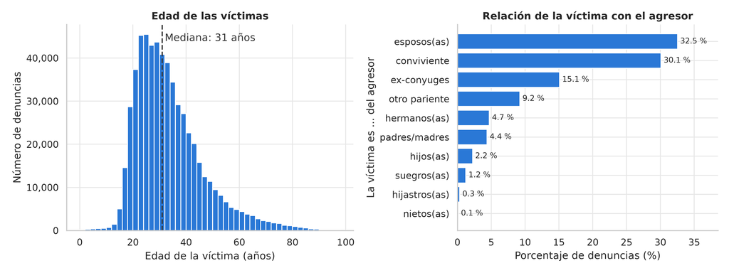

- **En el 83.0 % de las denuncias la víctima es una mujer y el agresor un hombre.** Las víctimas son mujeres en el 88.8 % de los casos y los agresores son hombres en el 86.7 %.
- La víctima típica es una **adulta joven**: mediana de 31 años, con la mitad de los casos entre 24 y 39. Los agresores son algo mayores (mediana de 33) y el 4.0 % de las víctimas son menores de edad.
- La violencia ocurre sobre todo **en la pareja**: esposo(a), conviviente o excónyuge suman el 77.7 % de los casos.

## 4.2 Tipos de violencia

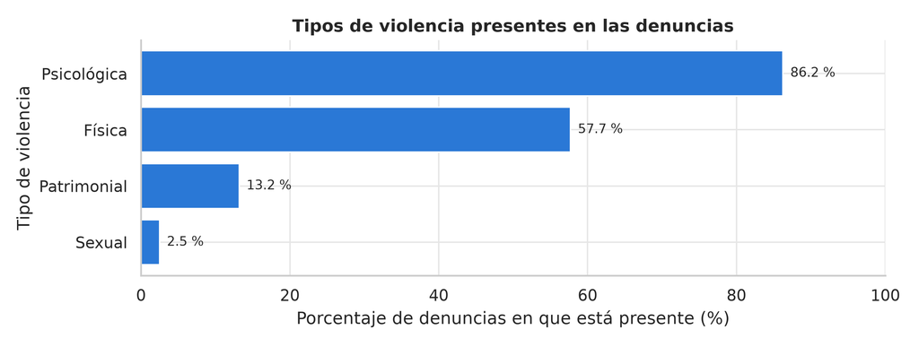

Una denuncia puede incluir varios tipos de violencia. La **psicológica** está presente en el 86.2 % de los casos y la **física** en el 57.7 %. Las combinaciones más comunes son física + psicológica (37.6 %) y solo psicológica (35.6 %). La violencia **sexual** (2.5 %) está casi con seguridad subregistrada: suele tramitarse por la vía penal o no se denuncia.

## 4.3 Relaciones entre variables

Casi todas las variables son categóricas, así que en lugar de la correlación de Pearson se usa la **V de Cramér**: 0 indica independencia y 1, asociación perfecta. Como guía, menos de 0.1 es una asociación despreciable, de 0.1 a 0.3 débil y más de 0.3 moderada.

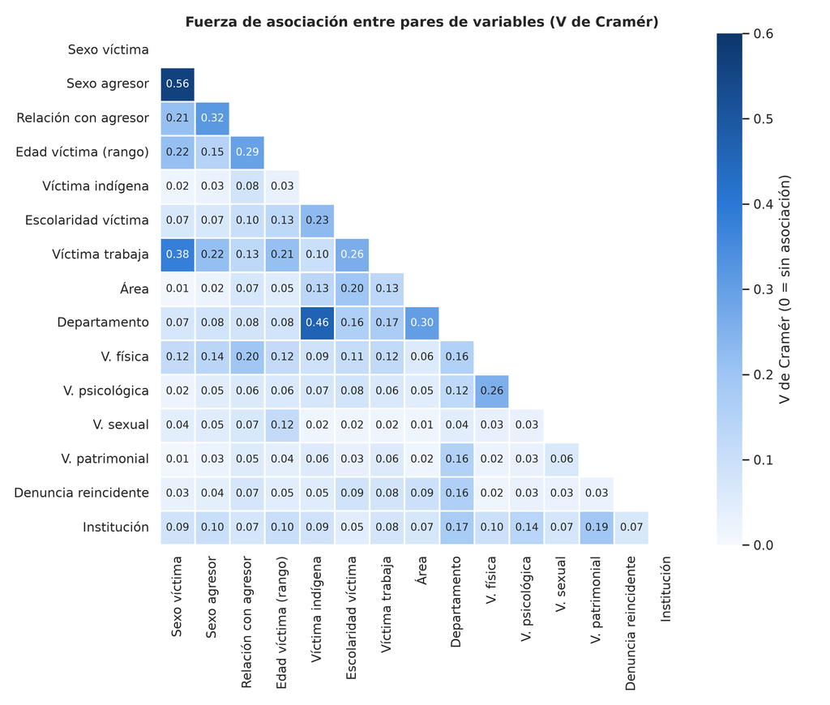

## 4.4 Dos fenómenos distintos: violencia de pareja y entre generaciones

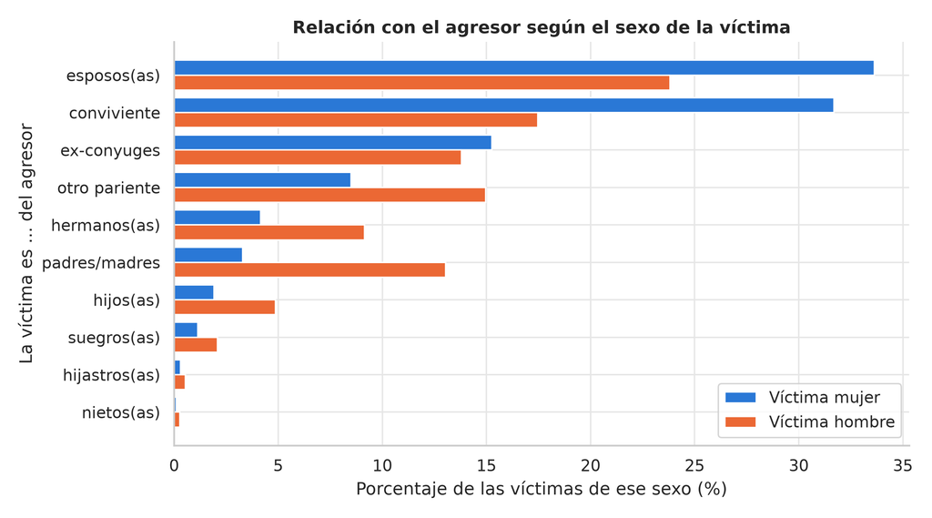

- **Mujeres**: el 81 % de los agresores son su pareja o expareja.
- **Hombres** (11.2 % de las víctimas): la pareja pesa menos (55 %), y en cambio pesan mucho los **hijos que agreden a su padre** (`padres/madres`, 13 %), los **hermanos** (9 %) y **otros parientes** (15 %).

Las denuncias mezclan dos fenómenos: la **violencia de pareja contra mujeres** (72 % del total) y la **violencia entre generaciones**, que afecta más a hombres y a adultos mayores. Conviene analizarlos por separado.

## 4.5 Violencia sexual según la edad y el sexo

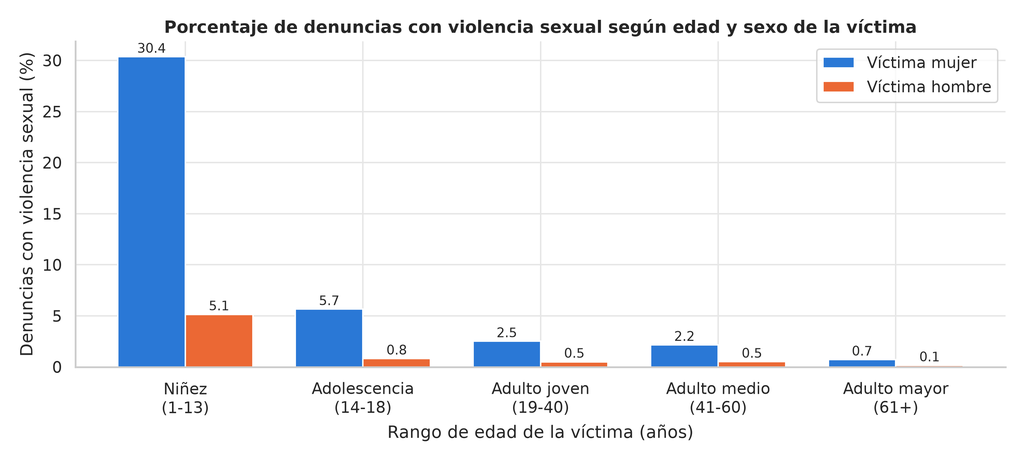

Es el contraste más fuerte del análisis: **el 30.4 % de las denuncias de niñas menores de 14 años incluye violencia sexual**, frente al 2.5 % en mujeres de 19 a 40. El grupo es pequeño (3,977 denuncias) y estos delitos se tramitan sobre todo por la vía penal, así que la cifra **subestima** el problema. La violencia sexual también es mucho mayor cuando la víctima es hijastra(o) o nieta(o) del agresor (Anexo C).

## 4.6 Evolución en el tiempo

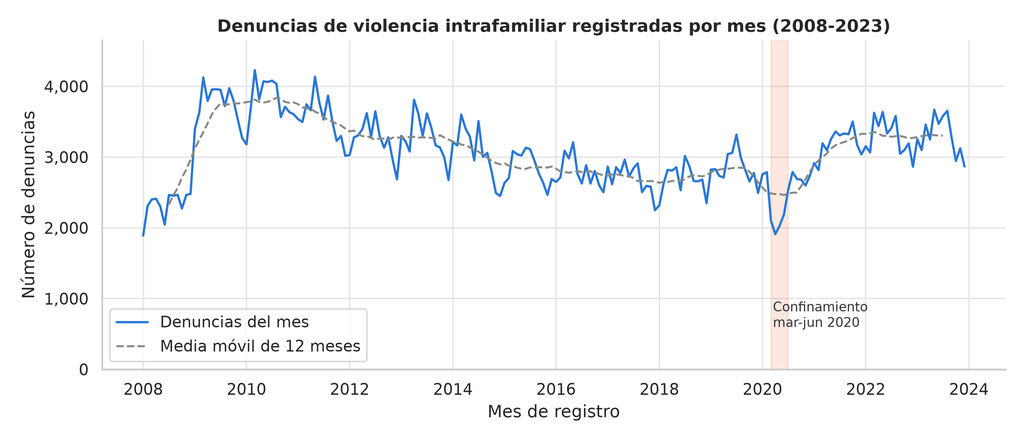

| Mes | Promedio 2017-2019 | 2020 | Cambio 2020 (%) |
| --- | --- | --- | --- |
| Mar | 2,804 | 2,103 | -25.0 |
| Abr | 2,765 | 1,911 | -30.9 |
| May | 2,955 | 2,029 | -31.3 |
| Jun | 2,772 | 2,189 | -21.0 |
| Jul | 3,059 | 2,536 | -17.1 |
| Ago | 2,926 | 2,788 | -4.7 |

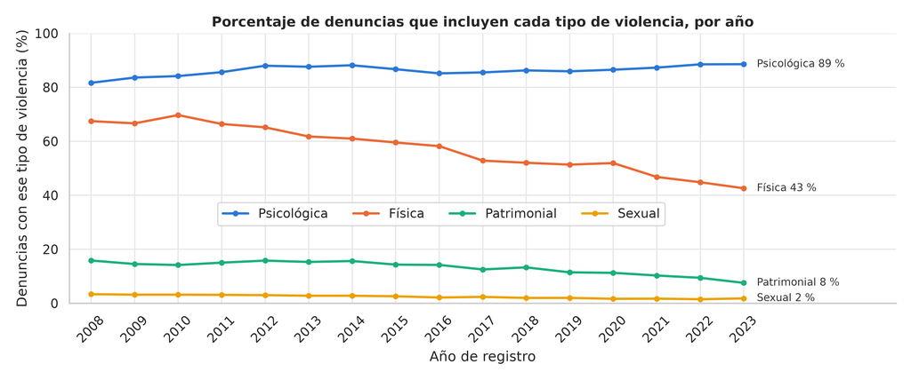

- La serie tiene tres fases: un **máximo en 2009-2011**, un **descenso gradual hasta 2018-2019** y una **recuperación desde 2021**.
- **Pandemia**: de marzo a junio de 2020 las denuncias cayeron entre 21 % y 31 % respecto al promedio de 2017-2019, durante las restricciones de movilidad. Con la víctima encerrada junto al agresor, la caída casi con seguridad **no significa menos violencia**.
- **La física pierde peso** (de 67 % a 43 %) **y la psicológica gana** (de 82 % a 89 %). Lo más probable es que cada vez más víctimas denuncien sin esperar a la agresión física, tras la difusión de la Ley contra el Femicidio (2008).

## 4.7 Diferencias territoriales

Para comparar departamentos se calcula la **tasa media anual de denuncias por cada 100 mil habitantes** según el departamento del hecho. Se usa la población del **Censo 2018** del INE, tomada como constante para todo el periodo (una aproximación).

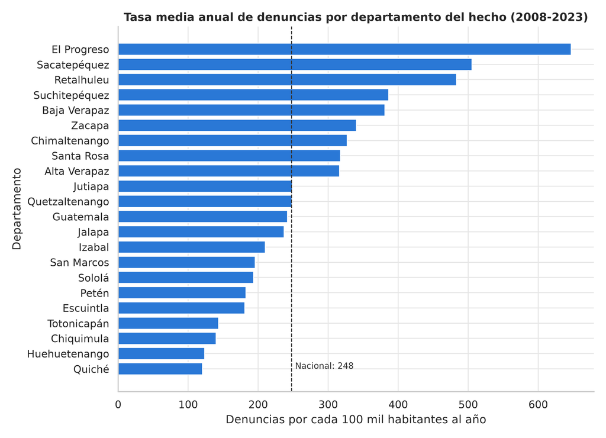

## 4.8 Modelo: factores asociados a la violencia física

Las comparaciones simples muestran que la violencia física es más frecuente en víctimas con menos escolaridad, indígenas y del área rural (Anexo A). Pero esas tres variables están relacionadas entre sí. Para separar sus efectos se ajusta una **regresión logística** con la presencia de violencia física como variable respuesta y como predictores la escolaridad, el pueblo, el área, la relación con el agresor (agrupada), el rango de edad, el sexo de la víctima y el año.

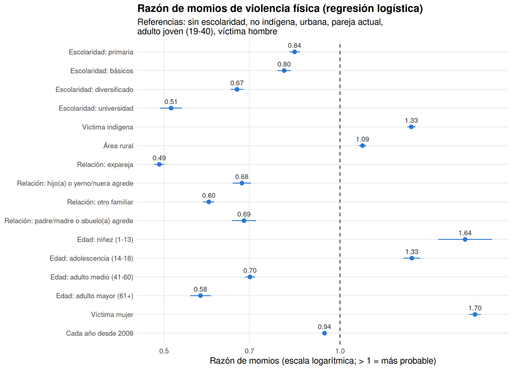

Evaluación del modelo en el conjunto de prueba (30 %)

| Métrica | Valor |
| --- | --- |
| AUC | 0.669 |
| Exactitud | 0.639 |
| Exactitud de referencia (clase mayoritaria) | 0.577 |
| Sensibilidad | 0.802 |
| Especificidad | 0.418 |
| Pseudo-R² de McFadden | 0.061 |

El modelo usa 478,702 denuncias con todos los datos (81 % del total). Una razón de momios (*odds ratio*) mayor que 1 indica que la violencia física es más probable que en la categoría de referencia, manteniendo constantes las demás variables.

# 5 Discusión

| Hallazgo | Evidencia | Interpretación |
| --- | --- | --- |
| Violencia de género y de pareja | Mujer víctima y hombre agresor en el 83 %; pareja o expareja en el 78 % | Dos fenómenos distintos (pareja y entre generaciones) que conviene analizar por separado |
| La violencia física pierde peso | 67 % a 43 % (2008-2023); razón de momios anual 0.94 en el modelo | Cambio en **qué se denuncia**; no prueba que haya menos violencia física |
| Riesgo sexual en niñas | 30 % en niñas menores de 14 vs. 3 % en adultas jóvenes | Grupo prioritario; cifra subestimada |
| Caída en el confinamiento | De -21 % a -31 % (marzo-junio de 2020) | Efecto de acceso a denunciar |
| Tasas bajas en el altiplano | Quiché 120 vs. nacional 248 por 100 mil | Hipótesis de **subregistro**, por confirmar con datos externos (ENSMI, juzgados por departamento) |
| Gradiente social en la violencia física | Razón de momios con universidad 0.51; indígena 1.33 | Efectos independientes pero pequeños; puede ser más violencia o una denuncia más tardía |

**Limitaciones del análisis.** (1) Los datos son denuncias, no prevalencia. (2) La población departamental es la de 2018 para todo el periodo. (3) El modelo es asociativo, no causal, y deja fuera el 19 % de casos con datos ignorados, que pueden diferir del resto. (4) Los tipos de violencia los registra la institución que recibe la denuncia y su criterio puede variar.

# 6 Conclusiones

1. **Perfil.** La violencia intrafamiliar denunciada en Guatemala es, sobre todo, **violencia de hombres contra mujeres en la pareja**. Junto a ella existe una violencia **entre generaciones** que explica buena parte de las víctimas hombres. La psicológica está casi siempre presente y la sexual se concentra en **niñas**.
2. **Tiempo.** Las denuncias alcanzaron su máximo en 2009-2011, cayeron con fuerza en el **confinamiento de 2020** y se recuperan desde 2021. Cada vez se denuncia más violencia psicológica sin violencia física.
3. **Territorio.** Con tasas por población, los departamentos pequeños y cercanos a la capital encabezan, y el **altiplano indígena** tiene las tasas más bajas, muy probablemente por **barreras de acceso a la justicia**.
4. **Factores asociados.** El sexo y la edad de la víctima, la convivencia en pareja, la escolaridad y el pueblo se asocian de forma independiente a la violencia física, pero en conjunto predicen poco (AUC de 0.67).

Lo más relevante que muestra este dataset es **quién llega a denunciar y quién no**. Mejorar el acceso a la denuncia en el área rural e indígena es tan importante como atender los casos que ya se registran.

# Referencias

- Congreso de la República de Guatemala (1996). *Decreto 97-96: Ley para Prevenir, Sancionar y Erradicar la Violencia Intrafamiliar*.
- Congreso de la República de Guatemala (2008). *Decreto 22-2008: Ley contra el Femicidio y otras Formas de Violencia contra la Mujer*.
- Congreso de la República de Guatemala (2017). *Decreto 13-2017: reformas al Código Civil (prohibición del matrimonio de menores de 18 años)*.
- DieggsPapu (2025). *Violencia Intrafamiliar en Guatemala INE 2008-2023* [conjunto de datos, versión 11]. Kaggle. https://www.kaggle.com/datasets/dieggspapu/violencia-intrafamiliar-en-guatemala-ine-2008-2023
- Instituto Nacional de Estadística de Guatemala (2019). *XII Censo Nacional de Población y VII de Vivienda 2018*. https://www.censopoblacion.gt/
- Instituto Nacional de Estadística de Guatemala. *Estadísticas de violencia intrafamiliar*. https://www.ine.gob.gt/
- R Core Team (2025). *R: A Language and Environment for Statistical Computing*. R Foundation for Statistical Computing.
- Ushey, K., Allaire, J. J. y Tang, Y. *reticulate: Interface to Python*. https://rstudio.github.io/reticulate/

# Anexos

## A. Perfil social de la víctima y violencia física

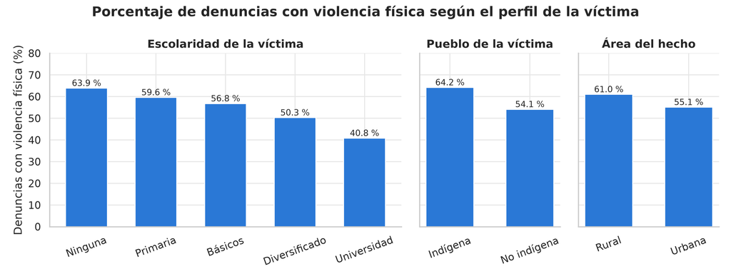

La violencia física baja al subir la escolaridad (de 64 % sin escolaridad a 41 % con universidad). También es más frecuente en víctimas indígenas (64 % frente a 54 %) y en el área rural (61 % frente a 55 %). El modelo de la sección de resultados separa estos efectos.

## B. Edades de víctima y agresor en parejas

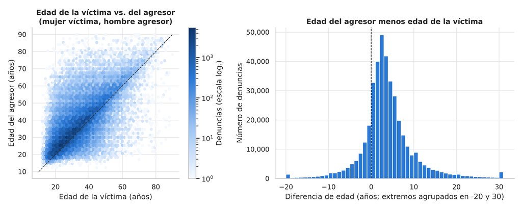

En las parejas las edades están muy correlacionadas (r = 0.79). El agresor es mayor que la víctima en el 74.0 % de los casos, con una diferencia mediana de 3 años, y le lleva 10 años o más en el 11.4 %. Los picos en 0, 5 y 10 años sugieren redondeo de edades.

## C. Tipo de violencia según la relación

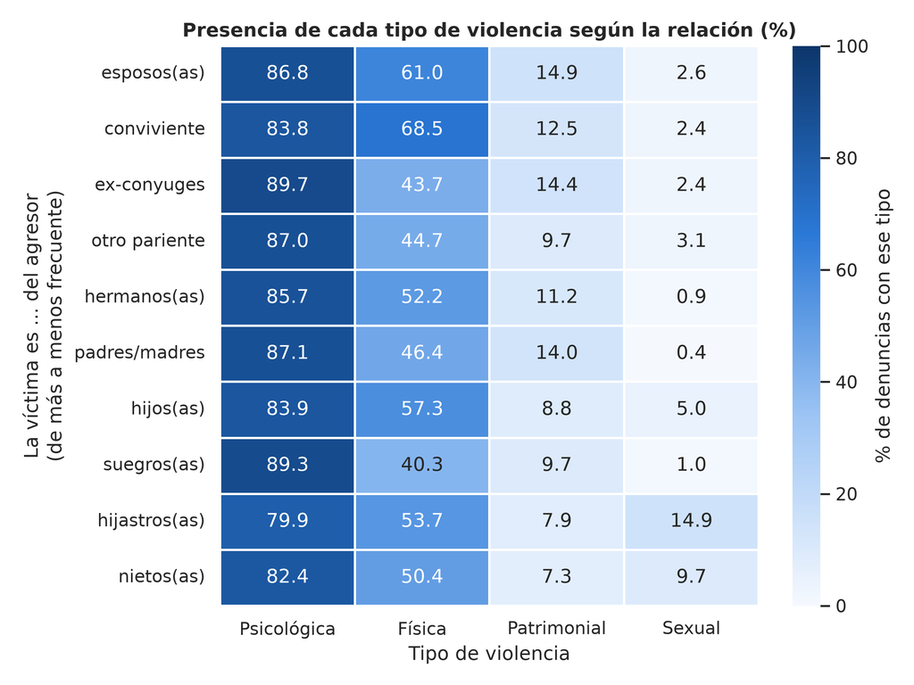

La física es mayor en las parejas actuales (68 % en convivientes) que en las exparejas (44 %). La sexual sube cuando la víctima es hijastra(o) (15 %), nieta(o) (10 %) o hija(o) (5 %) del agresor. La patrimonial destaca cuando un hijo agrede a sus padres (14 %).

## D. Autonomía económica, hijos y reincidencia

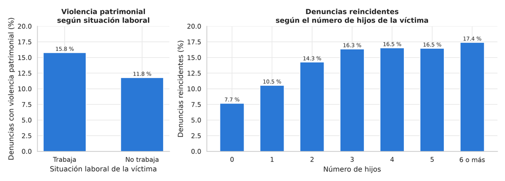

Contra lo esperado, las víctimas que **trabajan** reportan **más** violencia patrimonial (15.8 % frente a 11.8 %): con ingresos propios hay más que controlar o quitar. Las denuncias reincidentes suben con el número de hijos, del 7.7 % sin hijos al 17.4 % con seis o más, algo coherente con un vínculo que se mantiene a través de los hijos.

## E. Patrones del calendario

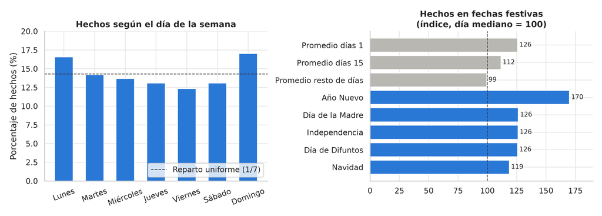

Los hechos se concentran en **domingo (17.0 %) y lunes (16.6 %)**; con un reparto uniforme cada día tendría 14.3 %. Los días 1 y 15 están inflados por **redondeo de fechas** (índices de 126 y 112, frente a 99 del resto). Aun así destacan **Año Nuevo** (170), el **Día de la Madre** (126) y el **Día de Difuntos** (126), celebraciones familiares con consumo de alcohol.

## F. Tasa de denuncias y porcentaje de víctimas indígenas

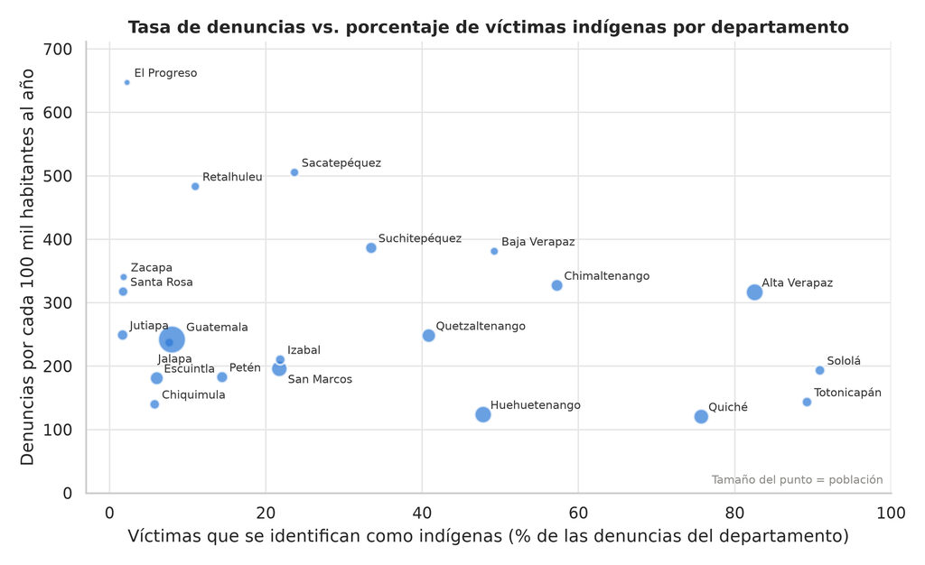

## G. Víctimas hombres por año

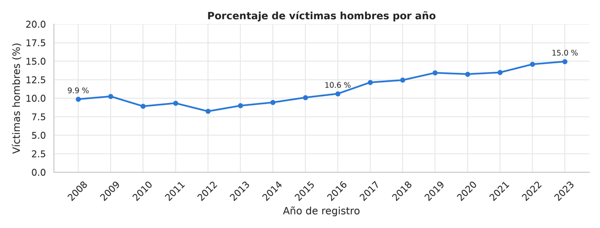

Las víctimas hombres pasaron del 9 % en 2010-2013 al 15 % en 2023. Puede reflejar más violencia contra hombres o menos reparo para denunciar; muchos casos son violencia entre generaciones.

## H. Respuesta institucional

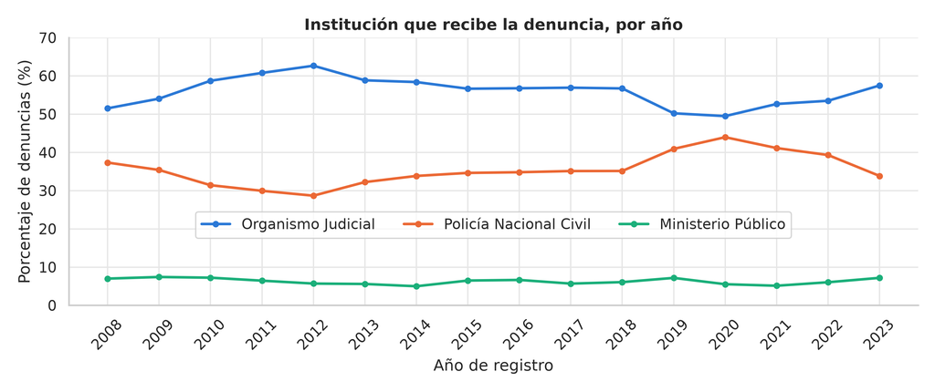

El **Organismo Judicial** recibe la mayoría de las denuncias. En la pandemia ganó peso la **PNC** (35 % en 2018, 44 % en 2020), que también recibe más denuncias en el área rural (39 % frente a 33 %). Las medidas de seguridad se otorgan en el 98 % de los casos con dato, pero ese dato existe solo en el 51 % de los registros.

## I. Entorno de ejecución

```
R: R version 4.5.2 (2025-10-31)
```

```
Python: 3.12.14 | pandas 3.0.5 | matplotlib 3.11.1
```

```
Paquetes de R: reticulate 1.46.0 | ggplot2 4.0.3 | knitr 1.51
```